# final_project

Teagan Norrgard, trn8cwf

11/24/2021

###First we read in our dataset.

Our dataset was obtained from Kaggle but the data itself was sourced from Inside Airbnb The first thing we did was read in our data.

```r
boston <- read.csv("/Users/teagannorrgard/3001final_project/Boston_Airbnb_copy.csv")
```

### Next we got to cleaning our data.

This included sub-setting columns we thought would make for interesting predictions, renaming columns so that they would be easier to call, and making ‘price’ and ‘cleaning_fee’ numeric variables.

```r
boston <- boston%>%
  select(c("name","neighbourhood_cleansed","latitude", "longitude", "room_type",
           "accommodates", "price", "cleaning_fee", "minimum_nights", "number_of_reviews",
           "review_scores_rating","host_response_rate", "host_acceptance_rate",
           "host_is_superhost", "amenities"))

boston <-  boston%>%
  rename(superhost = host_is_superhost, neighborhood = neighbourhood_cleansed)

boston$price = as.numeric(gsub("\\$", "", boston$price))
boston$cleaning_fee = as.numeric(gsub("\\$", "", boston$cleaning_fee))
```

### Then we made some basic exploration tables and visualizations.

Here we looked at neighborhood counts, and saw that the most popular neighborhoods are Jamaica Plain, South End, Back Bay, Fenway, Dorchester, and Allston.

```r
table(boston$neighborhood)
```

```
##
##                 Allston                Back Bay             Bay Village
##                     260                     302                      24
##             Beacon Hill                Brighton             Charlestown
##                     194                     185                     111
##               Chinatown              Dorchester                Downtown
##                      71                     269                     172
##             East Boston                  Fenway               Hyde Park
##                     150                     290                      31
##           Jamaica Plain        Leather District   Longwood Medical Area
##                     343                       5                       9
##                Mattapan            Mission Hill               North End
##                      24                     124                     143
##              Roslindale                 Roxbury            South Boston
##                      56                     144                     174
## South Boston Waterfront               South End                West End
##                      83                     326                      49
##            West Roxbury
##                      46
```

Here we made a table of the median values the numeric columns compared by neighborhood

```r
## could be interesting to compare to means
bost_med_table <- boston%>%
  group_by(neighborhood)%>%
  summarise(medianReview = median(review_scores_rating, na.rm=T), medianNumReviews = median(number_of_reviews, na.rm=T),
            medianPrice = median(price, na.rm=T), medianCleanFee = median(cleaning_fee, na.rm=T))

bost_med_table
```

```
## # A tibble: 25 × 5
##    neighborhood medianReview medianNumReviews medianPrice medianCleanFee
##    <chr>               <dbl>            <dbl>       <dbl>          <dbl>
##  1 Allston              94                2           85              35
##  2 Back Bay             93                6          209              75
##  3 Bay Village          93.5              2.5        206.            100
##  4 Beacon Hill          95                8.5        195              60
##  5 Brighton             94                4           90              45
##  6 Charlestown          96                4          178.             60
##  7 Chinatown            95                1          219             100
##  8 Dorchester           93                7           72              40
##  9 Downtown             94                4          225              95
## 10 East Boston          92               17           99              35
## # … with 15 more rows
```

And made a bar graph comparing the median prices by neighborhood.

[figure not shown]

```r
plot <- ggplot(data=bost_med_table, aes(x=neighborhood, y=medianPrice, fill=medianPrice))+
  scale_fill_gradient(low = "dark red", high = "cornflowerblue")+
  geom_bar(stat='identity')+
  theme(axis.text.x = element_text(angle=90))+
  labs(x="Neighborhood", y="Median Price of Airbnb per Night", title="Distribution of Airbnb prices per night over Neighborhoods in Boston")


plot
```

We made a table of the number of room types by neighborhood. It is important here to keep in mind the table of neighborhood counts

```r
boston%>%
  group_by(neighborhood)%>%
  select(room_type)%>%
  table()
```

```
##                          room_type
## neighborhood              Entire home/apt Private room Shared room
##   Allston                              98          156           6
##   Back Bay                            263           36           3
##   Bay Village                          20            4           0
##   Beacon Hill                         155           36           3
##   Brighton                             75          103           7
##   Charlestown                          68           42           1
##   Chinatown                            62            8           1
##   Dorchester                           66          195           8
##   Downtown                            144           24           4
##   East Boston                          70           77           3
##   Fenway                              208           73           9
##   Hyde Park                             6           24           1
##   Jamaica Plain                       157          181           5
##   Leather District                      3            2           0
##   Longwood Medical Area                 4            4           1
##   Mattapan                              3           21           0
##   Mission Hill                         48           68           8
##   North End                           119           21           3
##   Roslindale                           19           37           0
##   Roxbury                              58           81           5
##   South Boston                        102           69           3
##   South Boston Waterfront              71           12           0
##   South End                           250           69           7
##   West End                             43            6           0
##   West Roxbury                         15           29           2
```

And we see here that the top 100 most expensive Airbnbs are pretty evenly distributed over the neighborhoods. Back Bay has the highest number with 17 but doesn’t seem so high that it is an outlier. This also makes sense because Back Bay was one of the most popular neighborhoods in the first place

```r
boston_top100 <- boston%>%
  arrange(desc(price))

## we see here that the top 100 most expensive places are pretty evenly distributed over neighborhoods,
## Back Bay has the highest number with 17 but doesn't seem so high that it is an outlier.
## this also makes sense because Back Bay was one of the most popular neighborhoods in the first place
head(boston_top100, 100)%>%
  select(neighborhood)%>%
  table()
```

```
## .
##                 Allston                Back Bay             Bay Village
##                       3                      17                       5
##             Beacon Hill                Brighton             Charlestown
##                       9                       3                       4
##                Downtown                  Fenway           Jamaica Plain
##                       3                       6                      11
##            Mission Hill               North End                 Roxbury
##                       1                       2                       7
##            South Boston South Boston Waterfront               South End
##                       8                       7                      13
##                West End
##                       1
```

price, review_scores_rating one more?? to predict neighborhoods

is_host_superhost

use text analysis to predict rating (amenities, summary, description, space) use clustering to predict neighborhood

## Clustering

First we picked which variables we thought would do the best at predicting neighborhoods. We chose to use price and rating.

```r
clust_boston <- boston[, c("price", "review_scores_rating")]
```

```r
## a better thing to do would be replace with the median according to its neighborhood, but idk how to do that
sum(is.na(clust_boston$review_scores_rating))
```

```
## [1] 813
```

```r
sum(is.na(clust_boston$price))
```

```
## [1] 12
```

```r
clust_boston$review_scores_rating[is.na(clust_boston$review_scores_rating)] <- median(clust_boston$review_scores_rating, na.rm=T)
clust_boston$price[is.na(clust_boston$price)] <- median(clust_boston$price, na.rm=T)

sum(is.na(clust_boston$review_scores_rating))
```

```
## [1] 0
```

```r
sum(is.na(clust_boston$price))
```

```
## [1] 0
```

Then we used the elbow method to figure out how many clusters to choose.

```r
explained_variance = function(data_in, k){
  set.seed(1)
  kmeans_obj = kmeans(data_in, centers = k, algorithm = "Lloyd", iter.max = 30)
  var_exp = kmeans_obj$betweenss / kmeans_obj$totss
  var_exp
}



explained_var_boston = sapply(1:10, explained_variance, data_in = clust_boston)
explained_var_boston
```

```
##  [1] -1.579642e-14  6.057366e-01  7.788803e-01  8.845670e-01  9.174318e-01
##  [6]  9.288407e-01  9.334162e-01  9.516382e-01  9.537942e-01  9.549162e-01
```

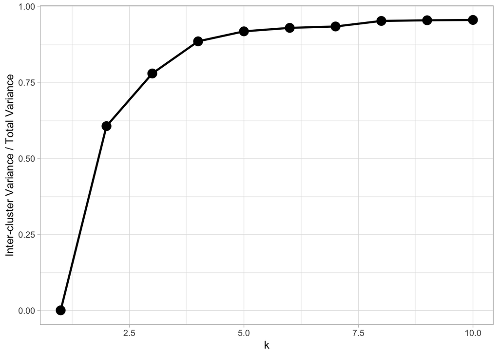

```r
elbow_boston = data.frame(k = 1:10, explained_var_boston)
ggplot(elbow_boston,
       aes(x = k,
           y = explained_var_boston)) +
  geom_point(size = 4) +
  geom_line(size = 1) +
  xlab('k') +
  ylab('Inter-cluster Variance / Total Variance') +
  theme_light()
```

Based on this graph, it looks like 4 clusters will give us the best model without overfitting.

Then we ran the clustering algorithm with 4 clusters

```r
set.seed(123)
kmeans_obj_boston = kmeans(clust_boston, centers = 4,
                        algorithm = "Lloyd")
clusters_boston = as.factor(kmeans_obj_boston$cluster)
```

And finally visualize the results

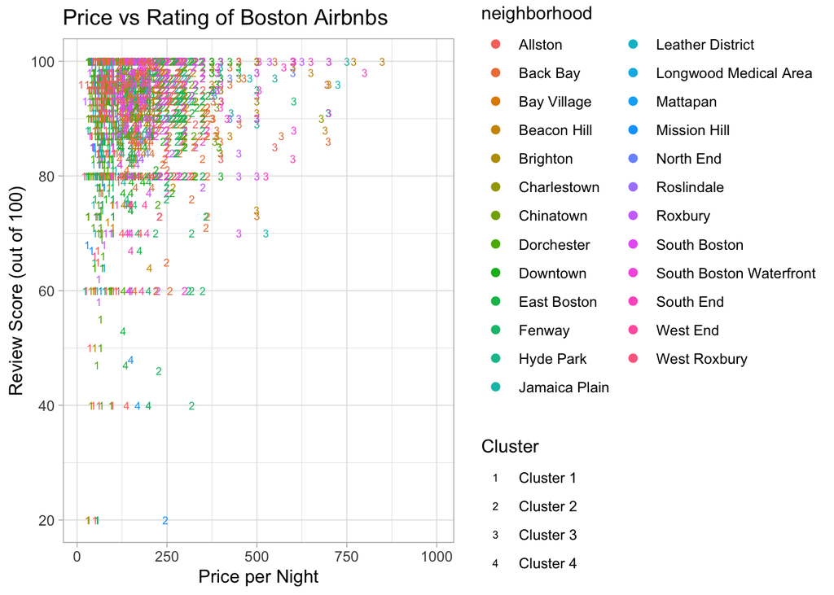

```r
## would this be  better if we manually grouped neighborhoods by location (factor collapse?)
## and then there wouldnt be 25 different things to look at

## also i will try to make a plotly graph later so that you can do the hover text

neighborhood_clusters = as.factor(kmeans_obj_boston$cluster)

ggplot(boston, aes(x = price,
                            y = review_scores_rating,
                            color = neighborhood,
                            shape = neighborhood_clusters)) +
  geom_point(size = 2) +
  ggtitle("Price vs Rating of Boston Airbnbs") +
  xlab("Price per Night") +
  ylab("Review Score (out of 100)") +
  scale_shape_manual(name = "Cluster",
                     labels = c("Cluster 1", "Cluster 2", "Cluster 3", "Cluster 4"),
                     values = c("1", "2", "3", "4")) +
  theme_light()
```